# Mortality_Analysis

This is a deep analysis of the mortality rate at different levels. It will start with the Statistics of Deaths in Bergamo , Italy. The Excess deaths , compared to historical data, will serve as a proxy to COVID 19 related deaths. The Excess deaths analysis has been published in the past, the following article explains it:

https://towardsdatascience.com/estimating-real-covid-19-death-toll-ef01a5eb9814

and contains a link to the dataset provided by ISTAT.

The focus the following analysis will be on Bergamo. A city of about 1.1 million people in the North of Italy and was the most affected during the pandemic. The assumption, which we expect to validate with comparisons to data from other countries, is that most of the population of this city was exposed directly to the virus. This assumption will serve as a basis to calculate an estimated mortality rate of the virus in that city.

All the files read into the code Chunks can be found in the following public One Drive. If the ready would like to rerun the code, download the files to your computer and change the directory reference in the read.csv functions.

https://1drv.ms/u/s!AqbXNILejy6xh9Mev5jB2ZEz41ypww?e=GgTWek

Published html file in

https://figueroaric.github.io/projects/Mortality_Analysis_covid.html

```r
ISTAT_data_deaths = read.csv("C:/Users/figue/Documents/Coronavirus/Mortality_Study/comuni_giornaliero.csv",stringsAsFactors = FALSE)

#Copy information for only Bergamo. Reduce to most important columns. Totals.

Deaths.Bergamo = ISTAT_data_deaths[ISTAT_data_deaths$NOME_PROVINCIA=="Bergamo",c("NOME_PROVINCIA","TIPO_COMUNE","CL_ETA","GE","T_15","T_16","T_17","T_18","T_19","T_20")]
#Have to clean n.d. and change it to 0

Deaths.Bergamo[,c("T_15","T_16","T_17","T_18","T_19","T_20")] = lapply(Deaths.Bergamo[,c("T_15","T_16","T_17","T_18","T_19","T_20")],function(x){ifelse(x=="n.d.",0,x)})


Deaths.Bergamo$T_20 = as.numeric(Deaths.Bergamo$T_20)
#Code Ages 0 to 21  0; 1-4 ; 5-9 ... 95-99 or 100+ . CL_ETA

#Deaths.Bergamo$CL_ETA*5 -1

Deaths.Bergamo$Age_Group = ifelse(Deaths.Bergamo$CL_ETA==0,"0",paste(Deaths.Bergamo$CL_ETA*5 -5,"-",Deaths.Bergamo$CL_ETA*5 -1," years",sep=""))

#quick agregation table by Age group. January to April each year

Deaths.Bergamo.Summary = aggregate(cbind(T_15,T_16,T_17,T_18,T_19,T_20) ~ Age_Group,data=Deaths.Bergamo, sum)

#Probably I have to find the period of maximum difference between January and April or would ab excess accross the 4 months
#Execss Accross 4 Months will be good.

#Average T_15 to T_19 then calculate difference with T_20

Deaths.Bergamo.Summary$Avg_15_2019 = apply(Deaths.Bergamo.Summary[,c("T_15","T_16","T_17","T_18","T_19")],1,mean)

Deaths.Bergamo.Summary$Excess_2020 = Deaths.Bergamo.Summary$T_20 - Deaths.Bergamo.Summary$Avg_15_2019

# Now will calculate the population by age  group for Bergamo for 2020 - January

ISTAT_population = read.csv("C:/Users/figue/Documents/Coronavirus/Mortality_Study/DCIS_POPRES1_08082020204807078_Bergamo.csv",stringsAsFactors = FALSE)
#only Bergamo and 2020

ISTAT_population = ISTAT_population[ISTAT_population$Territory=="Bergamo" & ISTAT_population$Select.time=="2020"&ISTAT_population$Gender=="total",]

#Have to group information by Year using variable value to add up

ISTAT_population$Age
```

```
##   [1] "0 years"            "1 years"            "2 years"
##   [4] "3 years"            "4 years"            "5 years"
##   [7] "6 years"            "7 years"            "8 years"
##  [10] "9 years"            "10 years"           "11 years"
##  [13] "12 years"           "13 years"           "14 years"
##  [16] "15 years"           "16 years"           "17 years"
##  [19] "18 years"           "19 years"           "20 years"
##  [22] "21 years"           "22 years"           "23 years"
##  [25] "24 years"           "25 years"           "26 years"
##  [28] "27 years"           "28 years"           "29 years"
##  [31] "30 years"           "31 years"           "32 years"
##  [34] "33 years"           "34 years"           "35 years"
##  [37] "36 years"           "37 years"           "38 years"
##  [40] "39 years"           "40 years"           "41 years"
##  [43] "42 years"           "43 years"           "44 years"
```

[output cut: 19 more lines]

```r
#Have to remove TOTAL

ISTAT_population = ISTAT_population[!(ISTAT_population$Age=="total"),]

#change Age to numeric using regular expressions
ISTAT_population$Age_Num = as.numeric(gsub("\\syear.+","",ISTAT_population$Age))
#Now create same rages to calculate additional mortality rate
#Use Mod %% with 5 plus division integer %/%

(ISTAT_population$Age_Num) %/% 5
```

```
##   [1]  0  0  0  0  0  1  1  1  1  1  2  2  2  2  2  3  3  3  3  3  4  4  4
##  [24]  4  4  5  5  5  5  5  6  6  6  6  6  7  7  7  7  7  8  8  8  8  8  9
##  [47]  9  9  9  9 10 10 10 10 10 11 11 11 11 11 12 12 12 12 12 13 13 13 13
##  [70] 13 14 14 14 14 14 15 15 15 15 15 16 16 16 16 16 17 17 17 17 17 18 18
##  [93] 18 18 18 19 19 19 19 19 20
```

```r
#the logic works but after 5 ; 5 to 9; 10 to 14..

ISTAT_population$Age_Group = ifelse(((ISTAT_population$Age_Num) %/% 5)==0, ifelse(ISTAT_population$Age_Num==0,"0",paste(((ISTAT_population$Age_Num) %/% 5)*5,"-",((ISTAT_population$Age_Num) %/% 5)*5 +4," years",sep="")),paste(((ISTAT_population$Age_Num) %/% 5)*5,"-",((ISTAT_population$Age_Num) %/% 5)*5 +4," years",sep=""))

##Have to fix and 100 years...
ISTAT_population[,c("Age_Group","Age_Num")]
```

|  | Age_Group | Age_Num |
| --- | --- | --- |
| 675 | 0 | 0 |
| 4860 | 0-4 years | 1 |
| 10718 | 0-4 years | 2 |
| 13600 | 0-4 years | 3 |
| 15808 | 0-4 years | 4 |
| 19024 | 5-9 years | 5 |
| 23117 | 5-9 years | 6 |
| 28155 | 5-9 years | 7 |
| 30933 | 5-9 years | 8 |
| 35394 | 5-9 years | 9 |

[output cut: 91 more lines]

```r
# Now aggregate value by age group

aggregate(Value ~ Age_Group ,ISTAT_population,sum)
```

| Age_Group | Value |
| --- | --- |
| 0 | 8252 |
| 0-4 years | 37108 |
| 10-14 years | 58521 |
| 100-104 years | 195 |
| 15-19 years | 57731 |
| 20-24 years | 57005 |
| 25-29 years | 56983 |
| 30-34 years | 60367 |
| 35-39 years | 67815 |
| 40-44 years | 80650 |

[output cut: 12 more lines]

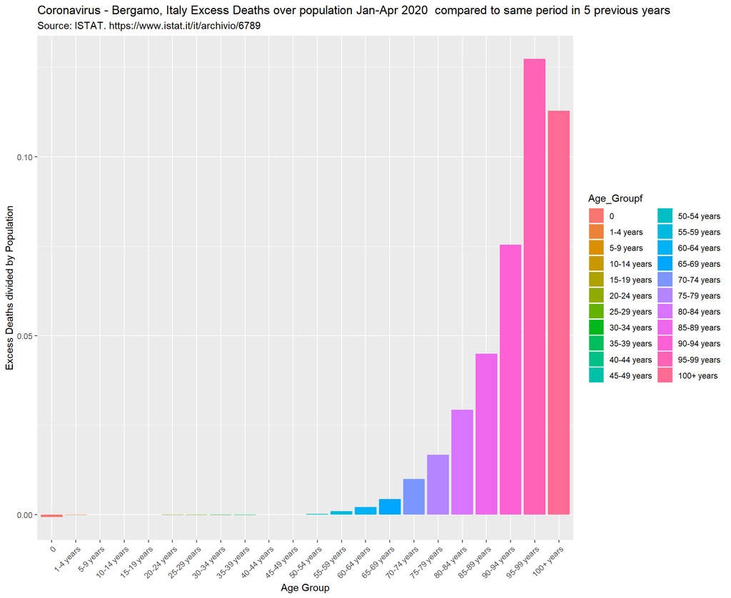

```r
ISTAT_population.summary = aggregate(Value ~ Age_Group ,ISTAT_population,sum)
#merge

Deaths.Bergamo.Summary = merge(Deaths.Bergamo.Summary, ISTAT_population.summary , by="Age_Group", all.x=TRUE, all.y = FALSE)

Deaths.Bergamo.Summary$ExcessD_over_Pop = Deaths.Bergamo.Summary$Excess_2020 / Deaths.Bergamo.Summary$Value

#0-4 years replace with 1-4 and 100-104 years replace 100+ years


#Have to create charts just % of excess deaths divided by population by age group.


Deaths.Bergamo.Summary[Deaths.Bergamo.Summary$Age_Group=="100-104 years", "Age_Group"]="100+ years"
Deaths.Bergamo.Summary[Deaths.Bergamo.Summary$Age_Group=="0-4 years", "Age_Group"]="1-4 years"

#order factors



Deaths.Bergamo.Summary$Age_Groupf <- factor(Deaths.Bergamo.Summary$Age_Group, levels = c("0","1-4 years","5-9 years","10-14 years","15-19 years","20-24 years","25-29 years","30-34 years","35-39 years","40-44 years","45-49 years","50-54 years","55-59 years","60-64 years","65-69 years","70-74 years","75-79 years","80-84 years","85-89 years","90-94 years","95-99 years","100+ years"))

#ggplot bars
library(ggplot2)

ggplot(Deaths.Bergamo.Summary, aes(x=Age_Groupf, y=ExcessD_over_Pop, fill = Age_Groupf))+geom_bar(stat="identity") + labs(subtitle="Source: ISTAT. https://www.istat.it/it/archivio/6789",
         title= "Coronavirus - Bergamo, Italy Excess Deaths over population Jan-Apr 2020  compared to same period in 5 previous years") + theme(axis.text.x = element_text(angle = 45, hjust = 1))  + xlab("Age Group") + ylab("Excess Deaths divided by Population")
```

```r
#From chart it is a good assumption to make that everyone was infected.
#It is very likely that not every one died of COVID 19 complications but the hospitals were overwhelmed
#This could explain the increase in deaths in the zero year old group

#Dividing all excess deaths by all population

sum(Deaths.Bergamo.Summary$Excess_2020) / sum(Deaths.Bergamo.Summary$Value)
```

```
## [1] 0.004480716
```

```r
#.00448   0.004%. Have to check orders in Bergamo. First case and when the came into lockdown

Deaths.Bergamo.Summary$Perc_Deaths = round(Deaths.Bergamo.Summary$ExcessD_over_Pop,6)

Deaths.Bergamo.Summary[,c("Age_Groupf","Perc_Deaths")]
```

| Age_Groupf | Perc_Deaths |
| --- | --- |
| 0 | -0.000654 |
| 1-4 years | -0.000016 |
| 10-14 years | 0.000021 |
| 100+ years | 0.112821 |
| 15-19 years | 0.000003 |
| 20-24 years | -0.000060 |
| 25-29 years | -0.000074 |
| 30-34 years | -0.000066 |
| 35-39 years | -0.000021 |
| 40-44 years | 0.000032 |

[output cut: 12 more lines]

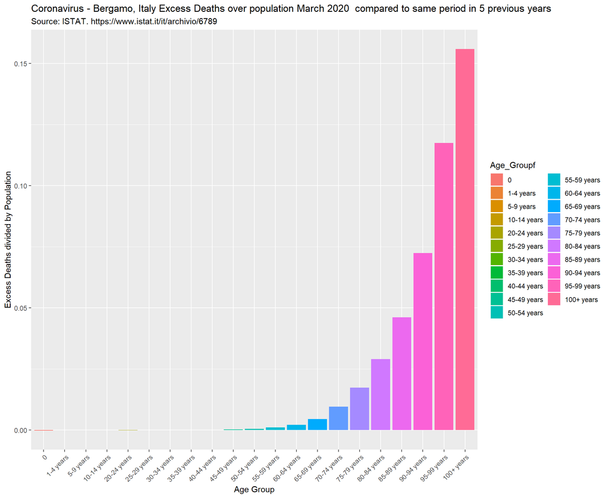

```r
#There are some negative numbers. Have to reduce the Window to only March?

Deaths.Bergamo = ISTAT_data_deaths[ISTAT_data_deaths$NOME_PROVINCIA=="Bergamo",c("NOME_PROVINCIA","TIPO_COMUNE","CL_ETA","GE","T_15","T_16","T_17","T_18","T_19","T_20")]
#Have to clean n.d. and change it to 0

Deaths.Bergamo[,c("T_15","T_16","T_17","T_18","T_19","T_20")] = lapply(Deaths.Bergamo[,c("T_15","T_16","T_17","T_18","T_19","T_20")],function(x){ifelse(x=="n.d.",0,x)})


Deaths.Bergamo$T_20 = as.numeric(Deaths.Bergamo$T_20)
#Code Ages 0 to 21  0; 1-4 ; 5-9 ... 95-99 or 100+ . CL_ETA

#Deaths.Bergamo$CL_ETA*5 -1

Deaths.Bergamo$Age_Group = ifelse(Deaths.Bergamo$CL_ETA==0,"0",paste(Deaths.Bergamo$CL_ETA*5 -5,"-",Deaths.Bergamo$CL_ETA*5 -1," years",sep=""))
#Use GE more than 300 and less than 400

Deaths.Bergamo=Deaths.Bergamo[Deaths.Bergamo$GE>300 & Deaths.Bergamo$GE<400,]

#quick agregation table by Age group. January to April each year

Deaths.Bergamo.Summary = aggregate(cbind(T_15,T_16,T_17,T_18,T_19,T_20) ~ Age_Group,data=Deaths.Bergamo, sum)

#Probably I have to find the period of maximum difference between January and April or would ab excess accross the 4 months
#Execss Accross 4 Months will be good.

#Average T_15 to T_19 then calculate difference with T_20

Deaths.Bergamo.Summary$Avg_15_2019 = apply(Deaths.Bergamo.Summary[,c("T_15","T_16","T_17","T_18","T_19")],1,mean)

Deaths.Bergamo.Summary$Excess_2020 = Deaths.Bergamo.Summary$T_20 - Deaths.Bergamo.Summary$Avg_15_2019


Deaths.Bergamo.Summary = merge(Deaths.Bergamo.Summary, ISTAT_population.summary , by="Age_Group", all.x=TRUE, all.y = FALSE)

Deaths.Bergamo.Summary$ExcessD_over_Pop = Deaths.Bergamo.Summary$Excess_2020 / Deaths.Bergamo.Summary$Value

#0-4 years replace with 1-4 and 100-104 years replace 100+ years


#Have to create charts just % of excess deaths divided by population by age group.


Deaths.Bergamo.Summary[Deaths.Bergamo.Summary$Age_Group=="100-104 years", "Age_Group"]="100+ years"
Deaths.Bergamo.Summary[Deaths.Bergamo.Summary$Age_Group=="0-4 years", "Age_Group"]="1-4 years"

#order factors



Deaths.Bergamo.Summary$Age_Groupf <- factor(Deaths.Bergamo.Summary$Age_Group, levels = c("0","1-4 years","5-9 years","10-14 years","15-19 years","20-24 years","25-29 years","30-34 years","35-39 years","40-44 years","45-49 years","50-54 years","55-59 years","60-64 years","65-69 years","70-74 years","75-79 years","80-84 years","85-89 years","90-94 years","95-99 years","100+ years"))

#ggplot bars
library(ggplot2)

ggplot(Deaths.Bergamo.Summary, aes(x=Age_Groupf, y=ExcessD_over_Pop, fill = Age_Groupf))+geom_bar(stat="identity") + labs(subtitle="Source: ISTAT. https://www.istat.it/it/archivio/6789",
         title= "Coronavirus - Bergamo, Italy Excess Deaths over population March 2020  compared to same period in 5 previous years") + theme(axis.text.x = element_text(angle = 45, hjust = 1))  + xlab("Age Group") + ylab("Excess Deaths divided by Population")
```

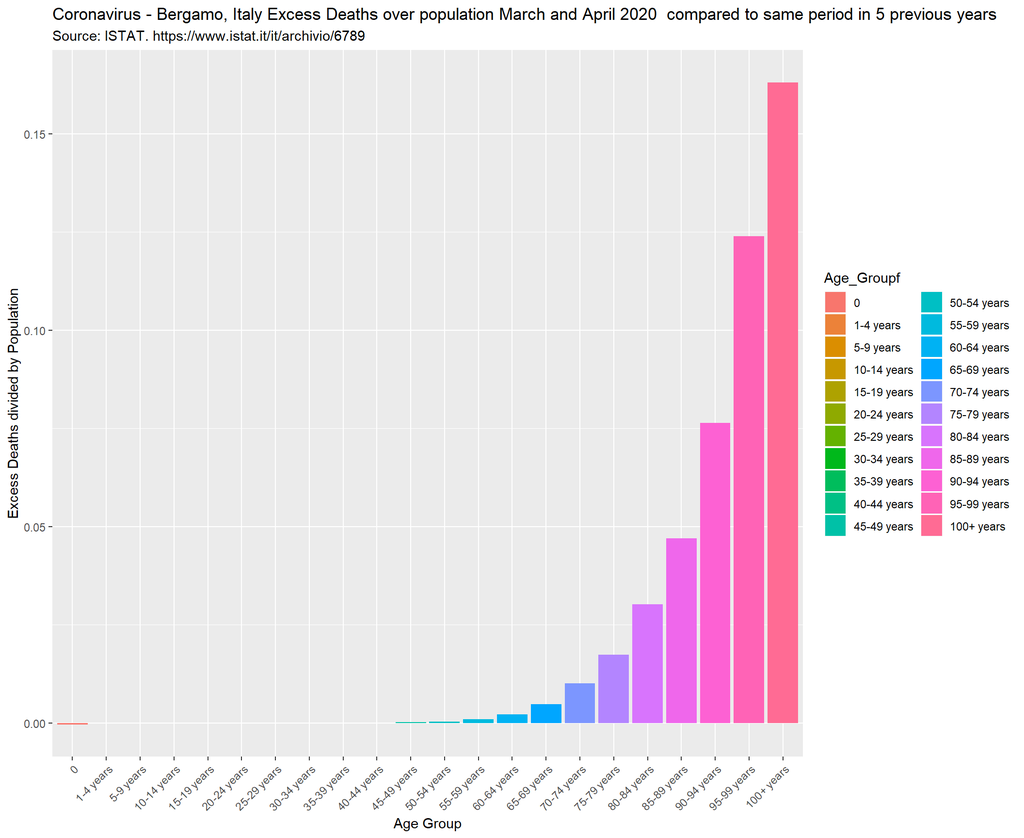

```r
#According to Germany and Korea data probably not everyone got infected or cannot get infected.



#March and April 2020

Deaths.Bergamo = ISTAT_data_deaths[ISTAT_data_deaths$NOME_PROVINCIA=="Bergamo",c("NOME_PROVINCIA","TIPO_COMUNE","CL_ETA","GE","T_15","T_16","T_17","T_18","T_19","T_20")]
#Have to clean n.d. and change it to 0

Deaths.Bergamo[,c("T_15","T_16","T_17","T_18","T_19","T_20")] = lapply(Deaths.Bergamo[,c("T_15","T_16","T_17","T_18","T_19","T_20")],function(x){ifelse(x=="n.d.",0,x)})


Deaths.Bergamo$T_20 = as.numeric(Deaths.Bergamo$T_20)
#Code Ages 0 to 21  0; 1-4 ; 5-9 ... 95-99 or 100+ . CL_ETA

#Deaths.Bergamo$CL_ETA*5 -1

Deaths.Bergamo$Age_Group = ifelse(Deaths.Bergamo$CL_ETA==0,"0",paste(Deaths.Bergamo$CL_ETA*5 -5,"-",Deaths.Bergamo$CL_ETA*5 -1," years",sep=""))
#Use GE more than 300 and less than 400

Deaths.Bergamo=Deaths.Bergamo[Deaths.Bergamo$GE>300,]

#quick agregation table by Age group. January to April each year

Deaths.Bergamo.Summary = aggregate(cbind(T_15,T_16,T_17,T_18,T_19,T_20) ~ Age_Group,data=Deaths.Bergamo, sum)

#Probably I have to find the period of maximum difference between January and April or would ab excess accross the 4 months
#Execss Accross 4 Months will be good.

#Average T_15 to T_19 then calculate difference with T_20

Deaths.Bergamo.Summary$Avg_15_2019 = apply(Deaths.Bergamo.Summary[,c("T_15","T_16","T_17","T_18","T_19")],1,mean)

Deaths.Bergamo.Summary$Excess_2020 = Deaths.Bergamo.Summary$T_20 - Deaths.Bergamo.Summary$Avg_15_2019


Deaths.Bergamo.Summary = merge(Deaths.Bergamo.Summary, ISTAT_population.summary , by="Age_Group", all.x=TRUE, all.y = FALSE)

Deaths.Bergamo.Summary$ExcessD_over_Pop = Deaths.Bergamo.Summary$Excess_2020 / Deaths.Bergamo.Summary$Value

#0-4 years replace with 1-4 and 100-104 years replace 100+ years


#Have to create charts just % of excess deaths divided by population by age group.


Deaths.Bergamo.Summary[Deaths.Bergamo.Summary$Age_Group=="100-104 years", "Age_Group"]="100+ years"
Deaths.Bergamo.Summary[Deaths.Bergamo.Summary$Age_Group=="0-4 years", "Age_Group"]="1-4 years"

#order factors



Deaths.Bergamo.Summary$Age_Groupf <- factor(Deaths.Bergamo.Summary$Age_Group, levels = c("0","1-4 years","5-9 years","10-14 years","15-19 years","20-24 years","25-29 years","30-34 years","35-39 years","40-44 years","45-49 years","50-54 years","55-59 years","60-64 years","65-69 years","70-74 years","75-79 years","80-84 years","85-89 years","90-94 years","95-99 years","100+ years"))
 #Keep a copy to use in NYC calculations
Deaths.Bergamo.Summary.NYC = Deaths.Bergamo.Summary

#ggplot bars
library(ggplot2)

ggplot(Deaths.Bergamo.Summary, aes(x=Age_Groupf, y=ExcessD_over_Pop, fill = Age_Groupf))+geom_bar(stat="identity") + labs(subtitle="Source: ISTAT. https://www.istat.it/it/archivio/6789",
         title= "Coronavirus - Bergamo, Italy Excess Deaths over population March and April 2020  compared to same period in 5 previous years") + theme(axis.text.x = element_text(angle = 45, hjust = 1))  + xlab("Age Group") + ylab("Excess Deaths divided by Population")
```

## Germany Looking for data in RKI

https://covid-19-geohub-deutschland-esridech.hub.arcgis.com/datasets/478220a4c454480e823b17327b2bf1d4

Dataset located

https://www.arcgis.com/home/item.html?id=f10774f1c63e40168479a1feb6c7ca74

Downloaded Aug 9th. This will be used to validate mortality rates. Official data and site

https://npgeo-corona-npgeo-de.hub.arcgis.com/

https://www.kaggle.com/mreverybody/covid19-data-germany-robert-koch-institute

Analysis of Germany Data. It will be helpful for distributions but not mortality rate. They have not tested a large portion of the population

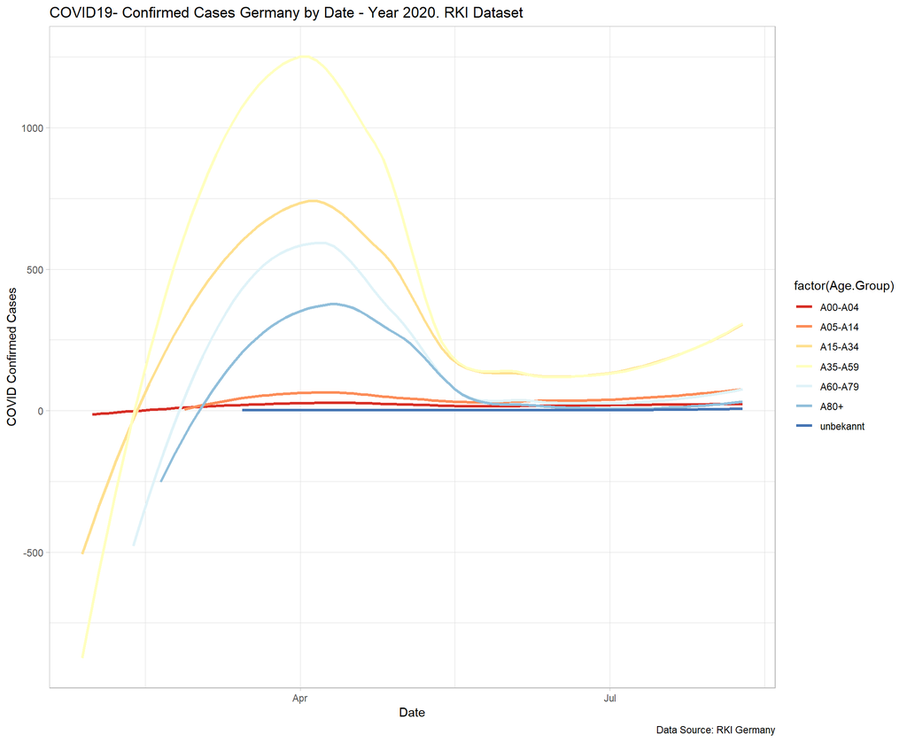

```r
library(ggplot2)
Germany.Data = read.csv("C:/Users/figue/Documents/Coronavirus/Mortality_Study/RKI_COVID19Aug9th.csv",stringsAsFactors = FALSE)

#will symmarize number of cases by Age Group and Number of deaths. But first validate what is the best period to analyze

Germany.Data$Reporting.Date = as.Date(Germany.Data$Reporting.Date, format="%m/%d/%Y")

#aggregate by reporting date. Cases and Deaths and Age

Germany.Cases.Date = aggregate(Number.of.cases ~ Age.Group + Reporting.Date,Germany.Data,sum)

Germany.Deaths.Date = aggregate(Number.Death ~ Age.Group + Reporting.Date,Germany.Data,sum)

# Confirmed Cases Plot

ggplot(Germany.Cases.Date , aes(x= Reporting.Date, y= Number.of.cases, group=Age.Group ))  + geom_smooth(method = "loess", aes(color = factor(Age.Group)),se=FALSE,size=1.2) + theme(legend.position="bottom",text = element_text(size=15)) + labs(title="COVID19- Confirmed Cases Germany by Date - Year 2020. RKI Dataset", y="COVID Confirmed Cases", x="Date", caption="Data Source: RKI Germany") +  scale_color_brewer(palette = "RdYlBu") + theme_light()
```

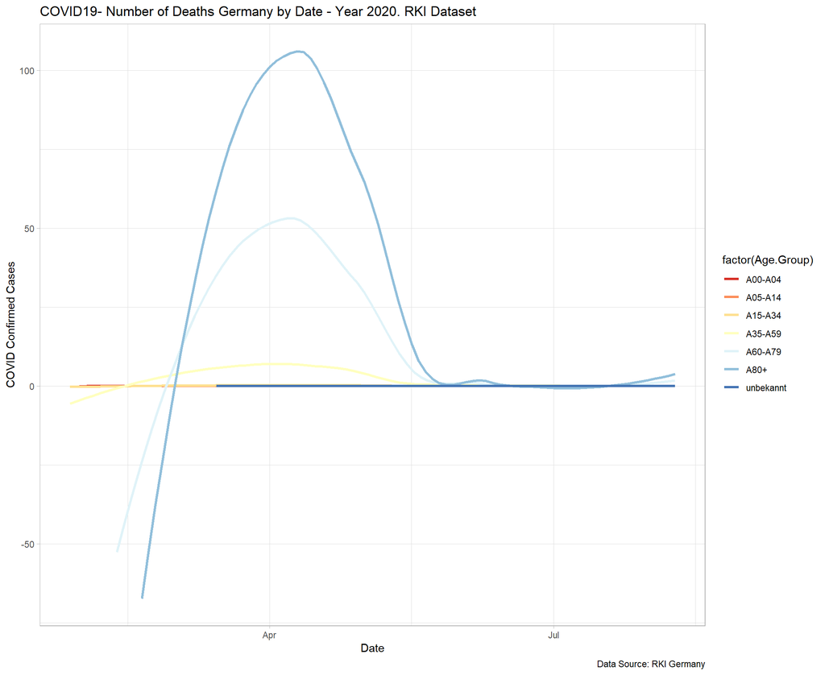

```r
#Deaths Plot


ggplot(Germany.Deaths.Date , aes(x= Reporting.Date, y= Number.Death, group=Age.Group ))  + geom_smooth(method = "loess", aes(color = factor(Age.Group)),se=FALSE,size=1.2) + theme(legend.position="bottom",text = element_text(size=15)) + labs(title="COVID19- Number of Deaths Germany by Date - Year 2020. RKI Dataset", y="COVID Confirmed Cases", x="Date", caption="Data Source: RKI Germany") +  scale_color_brewer(palette = "RdYlBu") + theme_light()
```

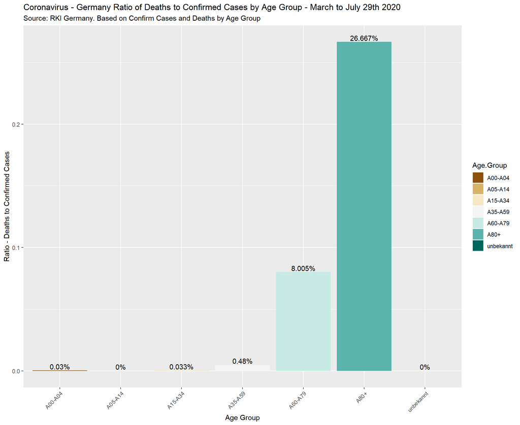

```r
#Calculate ratio of deaths by cofirmed cases but in total. No dates. Do it by age group

Germany.Cases = aggregate(Number.of.cases ~ Age.Group, Germany.Data,sum)

Germany.Deaths = aggregate(Number.Death ~ Age.Group, Germany.Data,sum)

#Will merge Cases and Deaths

Germany.Cases.Deaths = merge(Germany.Cases, Germany.Deaths, by = "Age.Group", all.x=TRUE, all.y=FALSE)

#Ration Deaths to confirmed cases

Germany.Cases.Deaths$Ratio.Deaths.Confirmed = Germany.Cases.Deaths$Number.Death / Germany.Cases.Deaths$Number.of.cases

Germany.Cases.Deaths$Ratio.Deaths.Confirmed = round(Germany.Cases.Deaths$Ratio.Deaths.Confirmed,5)

#Adding Percent will be necessary (will have to do the same for Italy)



Germany.Cases.Deaths$Percent = paste(Germany.Cases.Deaths$Ratio.Deaths.Confirmed*100,"%",sep="")

ggplot(Germany.Cases.Deaths, aes(x=Age.Group, y=Ratio.Deaths.Confirmed, fill = Age.Group))+geom_bar(stat="identity") + labs(subtitle="Source: RKI Germany. Based on Confirm Cases and Deaths by Age Group",
         title= "Coronavirus - Germany Ratio of Deaths to Confirmed Cases by Age Group - March to July 29th 2020") + theme(axis.text.x = element_text(angle = 45, hjust = 1)) + scale_fill_brewer(palette = "BrBG") + xlab("Age Group") + ylab("Ratio - Deaths to Confirmed Cases") + geom_text(aes(label=Percent), position=position_dodge(width=0.9), vjust=-0.25)
```

Likely the number of existing is higher than the confirmed cases. Specially for the older population. The ratios of deaths to confirmed cases look very high for population over 60 years old

## Now calculate for South Korea

This information is gathered from the Korea Centers for Disease Control and prepared by Data Scientist. This information was retrieved from Kaggle

https://www.kaggle.com/kimjihoo/ds4c-what-is-this-dataset-detailed-description

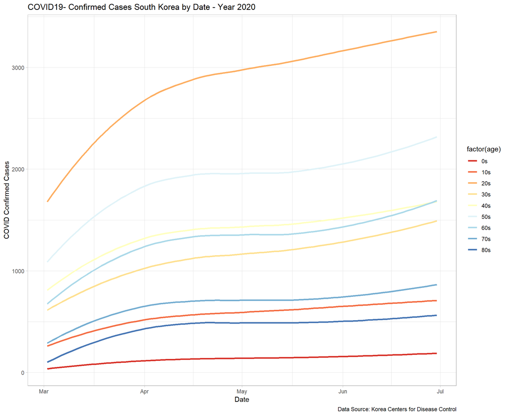

```r
Korea.Age = read.csv("C:/Users/figue/Documents/Coronavirus/Mortality_Study/archiveKorea/TimeAge.csv",stringsAsFactors = FALSE)
#change date to as.date

Korea.Age$date = as.Date(Korea.Age$date,format="%Y-%m-%d")

# can plot cummulative confirmed by Age

ggplot(Korea.Age , aes(x= date, y= confirmed, group=age ))  + geom_smooth(method = "loess", aes(color = factor(age)),se=FALSE,size=1.2) + theme(legend.position="bottom",text = element_text(size=15)) + labs(title="COVID19- Confirmed Cases South Korea by Date - Year 2020", y="COVID Confirmed Cases", x="Date", caption="Data Source: Korea Centers for Disease Control") +  scale_color_brewer(palette = "RdYlBu") + theme_light()
```

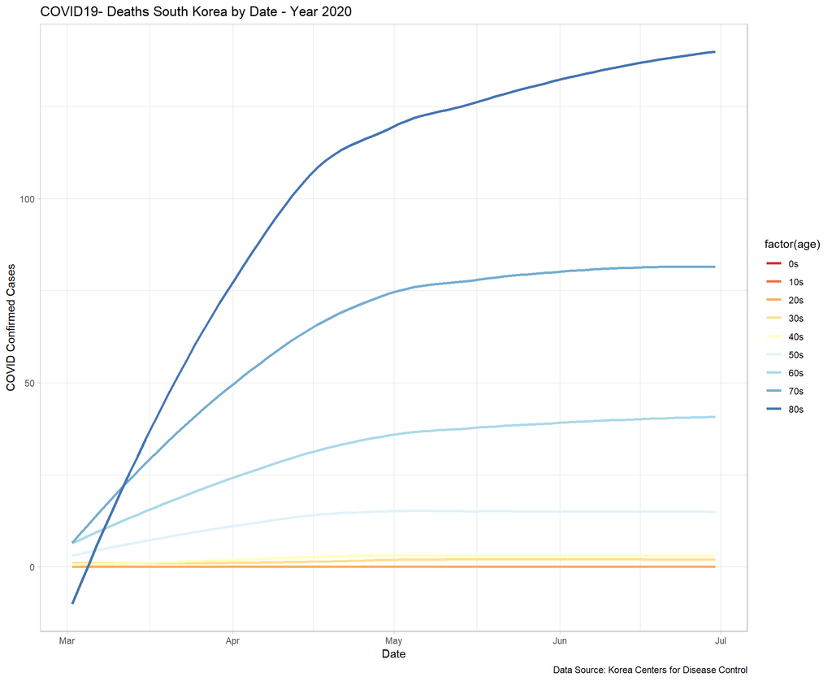

```r
# can plot cummulative deceased by Age

ggplot(Korea.Age , aes(x= date, y= deceased, group=age ))  + geom_smooth(method = "loess", aes(color = factor(age)),se=FALSE,size=1.2) + theme(legend.position="bottom",text = element_text(size=15)) + labs(title="COVID19- Deaths South Korea by Date - Year 2020", y="COVID Confirmed Cases", x="Date", caption="Data Source: Korea Centers for Disease Control") +  scale_color_brewer(palette = "RdYlBu") + theme_light()
```

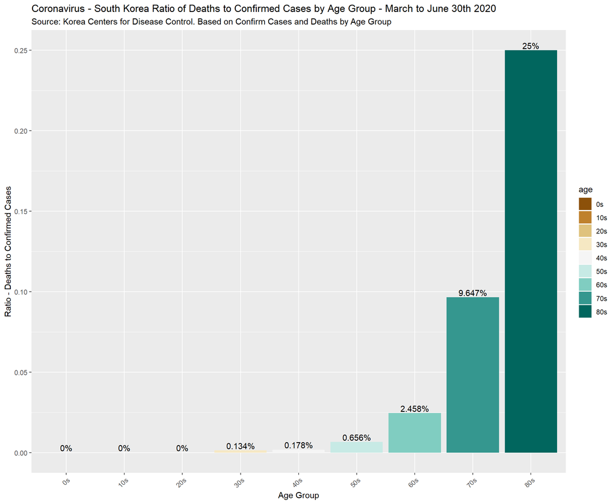

```r
#Now calculate Ratio Deaths to Confirmed cases
#use max date , it is 6-30

Korea.Age.Ratio = Korea.Age[Korea.Age$date==max(Korea.Age$date),]

Korea.Age.Ratio$Death.Confirmed.Ratio = Korea.Age.Ratio$deceased / Korea.Age.Ratio$confirmed

#Percentage

Korea.Age.Ratio$Percent = paste(round(Korea.Age.Ratio$Death.Confirmed.Ratio,5)*100,"%",sep="")

ggplot(Korea.Age.Ratio, aes(x=age, y=Death.Confirmed.Ratio, fill = age))+geom_bar(stat="identity") + labs(subtitle="Source: Korea Centers for Disease Control. Based on Confirm Cases and Deaths by Age Group",
         title= "Coronavirus - South Korea Ratio of Deaths to Confirmed Cases by Age Group - March to June 30th 2020") + theme(axis.text.x = element_text(angle = 45, hjust = 1)) + scale_fill_brewer(palette = "BrBG") + xlab("Age Group") + ylab("Ratio - Deaths to Confirmed Cases") + geom_text(aes(label=Percent), position=position_dodge(width=0.9), vjust=-0.25)
```

One more piece of information as reference for Singapore. Not easy to find by Age group. Scraped following website https://againstcovid19.com/singapore/cases/search

```r
#library(httr)
#library(XML)
#library(htmltab)
#library(rvest)

#check https://cran.r-project.org/web/packages/htmltab/vignettes/htmltab.html
#https://www.datacamp.com/community/tutorials/r-web-scraping-rvest
#try to use to rerieve data in

# scrape and download Singapore Data



#webpage <- read_html("https://againstcovid19.com/singapore/cases/search")

#tbls <- html_nodes(webpage, "table")

#head(tbls)

# empty list to add table data to
tbls2_ls <- list()

# scrape Table
#tbls2_ls$Table1 <- webpage %>%
#        html_nodes("#casesTable") %>%
#        html_table(fill = TRUE) %>%
 #       .[[1]]

#str(tbls2_ls)

#export 6588 observations Singapore

#head(tbls2_ls$Table1)

#write.csv(tbls2_ls$Table1,"C:/Users/figue/Documents/Coronavirus/Mortality_Study/Singapore_Age.csv",row.names = FALSE)
```

Load Singapore Data to do analysis by Age Group not that many cases and not new information

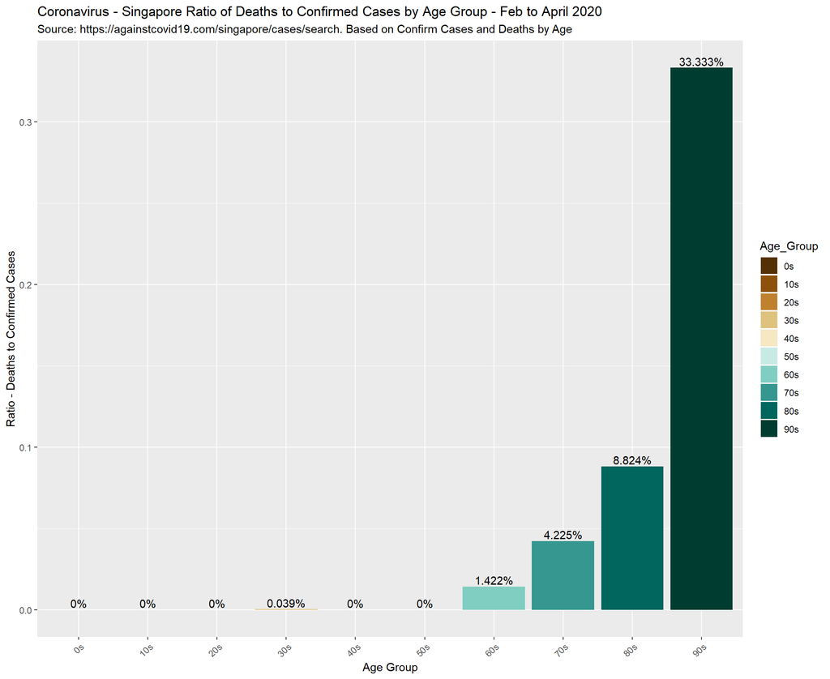

```r
Singapore.Age = read.csv("C:/Users/figue/Documents/Coronavirus/Mortality_Study/Singapore_Age.csv",stringsAsFactors = FALSE)
#will group in Age by 10s 0-9; 10-19 etc... to match to Germany and South Korea
#Status. Aggregate by Age and Status
#Let's use cut for grouping


#Age is character type
#first change to numeric to coerce NAs
Singapore.Age$Age=as.numeric(Singapore.Age$Age)
#remove 31 NAs

Singapore.Age = Singapore.Age[!is.na(Singapore.Age$Age),]

#Add age grouping name

Singapore.Age$Age_Group = paste((Singapore.Age$Age %/% 10)*10,"s",sep="")
#total cases by group
Singapore.Summary = aggregate(Case ~ Age_Group, data= Singapore.Age, length)

#There are only 11 Deceased

Singapore.Dec = aggregate(Case ~ Age_Group, data= Singapore.Age[Singapore.Age$Status == "Deceased",], length)

colnames(Singapore.Dec)= c("Age_Group","Decesead")

Singapore.Summary=merge(Singapore.Summary,Singapore.Dec,by="Age_Group" , all.x=TRUE, all.y=FALSE)

Singapore.Summary[is.na(Singapore.Summary$Decesead),"Decesead"]=0

Singapore.Summary$Death.Case.Ratio = Singapore.Summary$Decesead / Singapore.Summary$Case


#Percentage

Singapore.Summary$Percent = paste(round(Singapore.Summary$Death.Case.Ratio,5)*100,"%",sep="")
#remove 100s for ploting - create different dataframe

Singapore.Summary2=Singapore.Summary[Singapore.Summary$Age_Group!="100s",]

ggplot(Singapore.Summary2, aes(x=Age_Group, y=Death.Case.Ratio, fill = Age_Group))+geom_bar(stat="identity") + labs(subtitle="Source: https://againstcovid19.com/singapore/cases/search. Based on Confirm Cases and Deaths by Age",
         title= "Coronavirus - Singapore Ratio of Deaths to Confirmed Cases by Age Group - Feb to April 2020") + theme(axis.text.x = element_text(angle = 45, hjust = 1)) + scale_fill_brewer(palette = "BrBG") + xlab("Age Group") + ylab("Ratio - Deaths to Confirmed Cases") + geom_text(aes(label=Percent), position=position_dodge(width=0.9), vjust=-0.25)
```

```r
#Have to use Age ; any one over 64 years old
Singapore.Age.60older = Singapore.Age[Singapore.Age$Age>59,]
df = ifelse(Singapore.Age.60older$Status=="Deceased",1,0)

#Calculate error using bootstraping... also complete density function plot
set.seed(100)
times=10000
mean(replicate(times, sd(sample(df, replace=T))/sqrt(length(df))))
```

```
## [1] 0.009617191
```

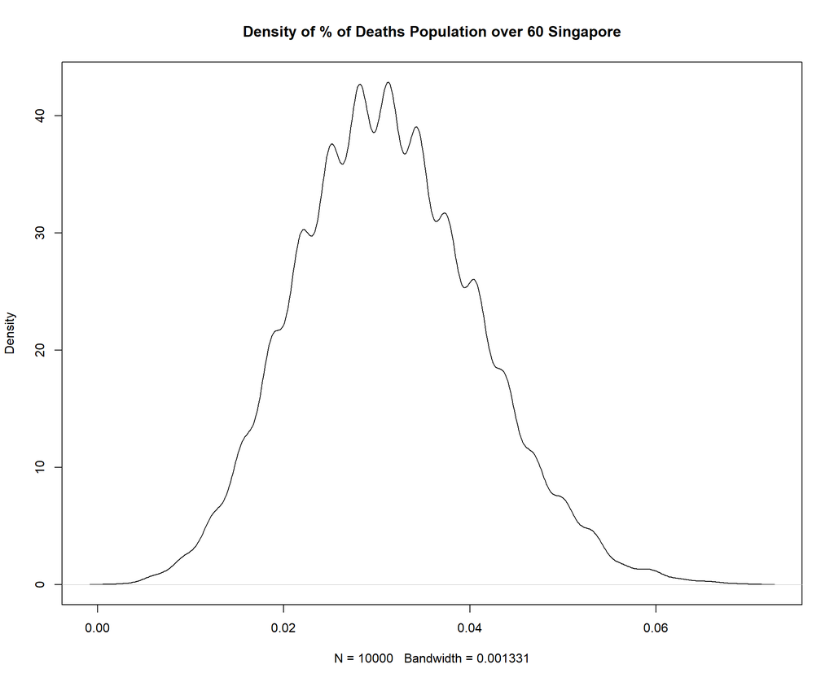

```r
#std of the mean 0.0096
#complete a density diagram of mean

calc_mean = mean(sample(df, replace=T))

for(i in 1:9999){
  calc_mean=c(calc_mean,mean(sample(df, replace=T)))
}
#actual mean is 0.03125
plot(density(calc_mean),main="Density of % of Deaths Population over 60 Singapore")
```

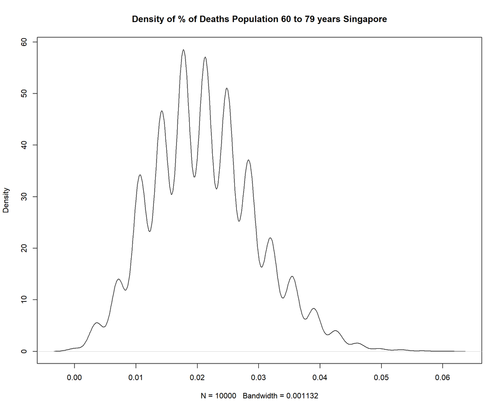

```r
#divide 60-79 and over 80

Singapore.Age.60to79 = Singapore.Age[Singapore.Age$Age>59 & Singapore.Age$Age<80,]

df = ifelse(Singapore.Age.60to79$Status=="Deceased",1,0)

calc_mean = mean(sample(df, replace=T))

for(i in 1:9999){
  calc_mean=c(calc_mean,mean(sample(df, replace=T)))
}
#actual mean is 0.03125
plot(density(calc_mean),main="Density of % of Deaths Population 60 to 79 years Singapore")
```

```r
mean(calc_mean)
```

```
## [1] 0.02121277
```

```r
sd(calc_mean)
```

```
## [1] 0.008550775
```

```r
#stamdard deviation .008 to high

#May 8th 2020 Information
#https://www.moh.gov.sg/news-highlights/details/support-measures-for-seniors-during-COVID-19

#412 cases 60 or older
#95% of deaths on May 8th...there were 20 deaths so 19 were elderly
# Have to use News in order to fill in the details for the additional 9 deaths in the elderly
#https://www.moh.gov.sg/news-highlights/
#The current file has information up to April 19th
#And the Last deaths in the elderly were capture as of May 8th
#Case 1071 died on April 21st
#Cases 1595 and 9682 died on  April 27th
#Case 703 died April 30th
#Case Case 2728 died on May 1st
#Case 1323 died on May 1st
#Case Case 14744 died on May 3rd
#Case 1414 died May 5th
#Case 1528 died May 6th

#In addition to adding this, I have to add dummy cases that have not died in age groups 60s, 70s, 80s and 90s keeping same  distribution of ages
#to get to 412 cases. Currently I have 322 so 90 have to be added.

table(Singapore.Age$Age_Group)
```

```
##
##   0s 100s  10s  20s  30s  40s  50s  60s  70s  80s  90s
##   32    1   59 1989 2563 1139  455  211   71   34    3
```

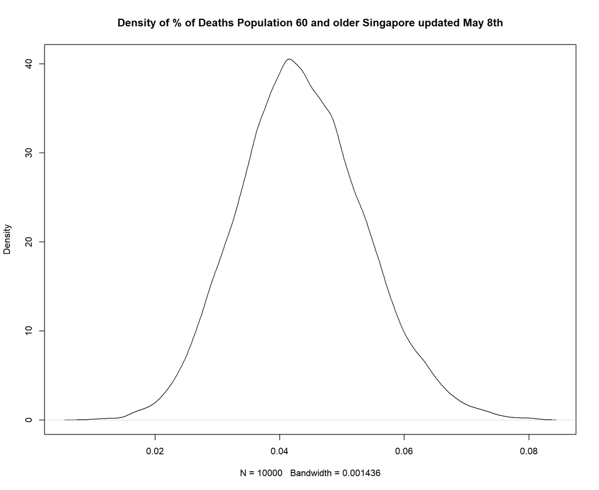

```r
#Load file and add Dummy entries

#Singapore_Age_Updated_Elderly.csv

Singapore.Age.elderly = read.csv("C:/Users/figue/Documents/Coronavirus/Mortality_Study/Singapore_Age_Updated_Elderly.csv",stringsAsFactors = FALSE)
#I want population 59 and acording to May 8th 2020 report there should be a total of 412 cases

#Age is character type
#first change to numeric to coerce NAs
Singapore.Age.elderly$Age=as.numeric(Singapore.Age.elderly$Age)
#remove 31 NAs

Singapore.Age.elderly = Singapore.Age.elderly[!is.na(Singapore.Age.elderly$Age),]

#remove anyone 59 or younger
Singapore.Age.elderly = Singapore.Age.elderly[Singapore.Age.elderly$Age>59,]
#Add age grouping name

Singapore.Age.elderly$Age_Group = paste((Singapore.Age.elderly$Age %/% 10)*10,"s",sep="")
#there are 322 cases and need 412 have to add 90. Divided in 3 groups 60s 70s and older than 80s. Check distribution

tempoeld = table(Singapore.Age.elderly$Age_Group)
total80andup = sum(tempoeld[c("80s","90s","100s")])
tempoeld=tempoeld[names(tempoeld)%in%c("60s","70s")]

tempoeld["A80+"]=total80andup

#it is not removing 100s
tempoeld=tempoeld[names(tempoeld)!="100s"]
#Percentages and then calculate distribution
tempoeld.dis = tempoeld/sum(tempoeld)

tempoeld.dis=tempoeld.dis*90

tempoeld.dis=round(tempoeld.dis,0)
#All new records will be marked as in hospital

#create entries for 60s. 59 records
for(i in 1:59){
Singapore.Age.elderly=rbind(Singapore.Age.elderly,data.frame(Case=100000,Patient="Dummy 65 year old",Age=65,Gender="Dummy",Nationality="Dummy",Status="In hospital",Infection.Source="Dummy",Country.of.Origin="Dummy",Symptomatic.ToConfirmation="-",Days.ToRecover="-",Symptomatic.At="8th, May 2020",Confirmed.At="8th, May 2020",Recovered.At="-",Displayed.Symptoms.=TRUE,Age_Group="60s"))
}

#create entries for 70s. 20 records
for(i in 1:20){
Singapore.Age.elderly=rbind(Singapore.Age.elderly,data.frame(Case=100000,Patient="Dummy 75 year old",Age=75,Gender="Dummy",Nationality="Dummy",Status="In hospital",Infection.Source="Dummy",Country.of.Origin="Dummy",Symptomatic.ToConfirmation="-",Days.ToRecover="-",Symptomatic.At="8th, May 2020",Confirmed.At="8th, May 2020",Recovered.At="-",Displayed.Symptoms.=TRUE,Age_Group="70s"))
}

#create entries for 80s. 11 records
for(i in 1:11){
Singapore.Age.elderly=rbind(Singapore.Age.elderly,data.frame(Case=100000,Patient="Dummy 85 year old",Age=85,Gender="Dummy",Nationality="Dummy",Status="In hospital",Infection.Source="Dummy",Country.of.Origin="Dummy",Symptomatic.ToConfirmation="-",Days.ToRecover="-",Symptomatic.At="8th, May 2020",Confirmed.At="8th, May 2020",Recovered.At="-",Displayed.Symptoms.=TRUE,Age_Group="80s"))
}

df = ifelse(Singapore.Age.elderly$Status=="Deceased",1,0)

calc_mean = mean(sample(df, replace=T))

for(i in 1:9999){
  calc_mean=c(calc_mean,mean(sample(df, replace=T)))
}
#actual mean is 0.03125
plot(density(calc_mean),main="Density of % of Deaths Population 60 and older Singapore updated May 8th")
```

```r
mean(calc_mean)
```

```
## [1] 0.04354296
```

```r
#4.3% with May 8th 2020 updates
sd(calc_mean)
```

```
## [1] 0.01006512
```

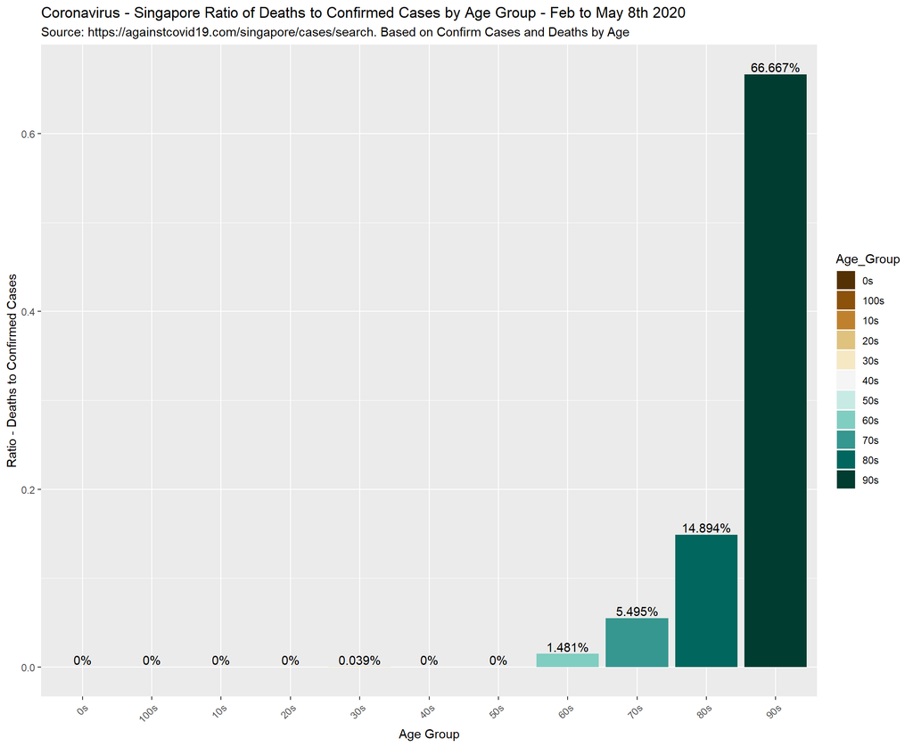

```r
#0.01 or 1% of standard deviation

#Will add information forpopulation under 60 to Singapore.Age.elderly

Singapore.Age.elderly=rbind(Singapore.Age.elderly,Singapore.Age[Singapore.Age$Age<60,])



#have to add values and percentages




#There are only 19 Deceased

Singapore.Dec = aggregate(Case ~ Age_Group, data= Singapore.Age.elderly[Singapore.Age.elderly$Status == "Deceased",], length)

Singapore.Summary.elderly = aggregate(Case ~ Age_Group, data= Singapore.Age.elderly, length)

colnames(Singapore.Dec)= c("Age_Group","Decesead")

Singapore.Summary.elderly=merge(Singapore.Summary.elderly,Singapore.Dec,by="Age_Group" , all.x=TRUE, all.y=FALSE)

Singapore.Summary.elderly[is.na(Singapore.Summary.elderly$Decesead),"Decesead"]=0

Singapore.Summary.elderly$Death.Case.Ratio = Singapore.Summary.elderly$Decesead / Singapore.Summary.elderly$Case


#Percentage

Singapore.Summary.elderly$Percent = paste(round(Singapore.Summary.elderly$Death.Case.Ratio,5)*100,"%",sep="")
#remove 100s for ploting - create different dataframe
#instead of removing 100s update to 90s, add one case


ggplot(Singapore.Summary.elderly, aes(x=Age_Group, y=Death.Case.Ratio, fill = Age_Group))+geom_bar(stat="identity") + labs(subtitle="Source: https://againstcovid19.com/singapore/cases/search. Based on Confirm Cases and Deaths by Age",
         title= "Coronavirus - Singapore Ratio of Deaths to Confirmed Cases by Age Group - Feb to May 8th 2020") + theme(axis.text.x = element_text(angle = 45, hjust = 1)) + scale_fill_brewer(palette = "BrBG") + xlab("Age Group") + ylab("Ratio - Deaths to Confirmed Cases") + geom_text(aes(label=Percent), position=position_dodge(width=0.9), vjust=-0.25)
```

```r
write.csv(Singapore.Age.elderly,"C:/Users/figue/Documents/Coronavirus/Mortality_Study/Singapore_Age_Updated_Elderly_cons.csv")

Singapore.Summary.elderly.wo.100 = Singapore.Summary.elderly

Singapore.Summary.elderly.wo.100[Singapore.Summary.elderly.wo.100$Age_Group=="90s","Case"] = Singapore.Summary.elderly.wo.100[Singapore.Summary.elderly.wo.100$Age_Group=="90s","Case"]+1

#remove 100s and recalculate Death.Case.Ration for 90s

Singapore.Summary.elderly.wo.100[Singapore.Summary.elderly.wo.100$Age_Group!="100s",]
```

|  | Age_Group | Case | Decesead | Death.Case.Ratio | Percent |
| --- | --- | --- | --- | --- | --- |
| 1 | 0s | 32 | 0 | 0.0000000000 | 0% |
| 3 | 10s | 59 | 0 | 0.0000000000 | 0% |
| 4 | 20s | 1989 | 0 | 0.0000000000 | 0% |
| 5 | 30s | 2563 | 1 | 0.0003901678 | 0.039% |
| 6 | 40s | 1139 | 0 | 0.0000000000 | 0% |
| 7 | 50s | 455 | 0 | 0.0000000000 | 0% |
| 8 | 60s | 270 | 4 | 0.0148148148 | 1.481% |
| 9 | 70s | 91 | 5 | 0.0549450549 | 5.495% |
| 10 | 80s | 47 | 7 | 0.1489361702 | 14.894% |
| 11 | 90s | 4 | 2 | 0.6666666667 | 66.667% |

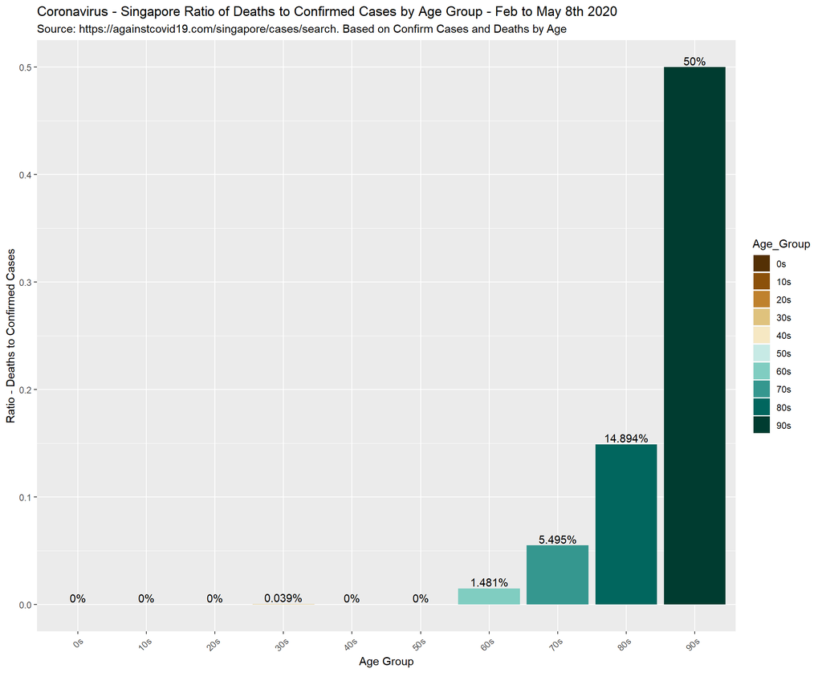

```r
Singapore.Summary.elderly.wo.100=Singapore.Summary.elderly.wo.100[Singapore.Summary.elderly.wo.100$Age_Group!="100s",]

Singapore.Summary.elderly.wo.100[Singapore.Summary.elderly.wo.100$Age_Group=="90s","Death.Case.Ratio"] = Singapore.Summary.elderly.wo.100[Singapore.Summary.elderly.wo.100$Age_Group=="90s","Decesead"]/ Singapore.Summary.elderly.wo.100[Singapore.Summary.elderly.wo.100$Age_Group=="90s","Case"]
#recalculate percent column
Singapore.Summary.elderly.wo.100$Percent = paste(round(Singapore.Summary.elderly.wo.100$Death.Case.Ratio,5)*100,"%",sep="")

ggplot(Singapore.Summary.elderly.wo.100, aes(x=Age_Group, y=Death.Case.Ratio, fill = Age_Group))+geom_bar(stat="identity") + labs(subtitle="Source: https://againstcovid19.com/singapore/cases/search. Based on Confirm Cases and Deaths by Age",
         title= "Coronavirus - Singapore Ratio of Deaths to Confirmed Cases by Age Group - Feb to May 8th 2020") + theme(axis.text.x = element_text(angle = 45, hjust = 1)) + scale_fill_brewer(palette = "BrBG") + xlab("Age Group") + ylab("Ratio - Deaths to Confirmed Cases") + geom_text(aes(label=Percent), position=position_dodge(width=0.9), vjust=-0.25)
```

Will bring together and compare information between Germany, South Korea and Singapore.

For Germany the Age Groups are A00-A04 ; A05-A14; A15 - A34; A35-A59 ; A60-A79 an d A80+

In order to congerge the Datasets we will use

A00-A19 ; A20-A34 ; A35-A59 ; A60-A79; A80+

Some assumptions will have to be made in order to compare the datasets.

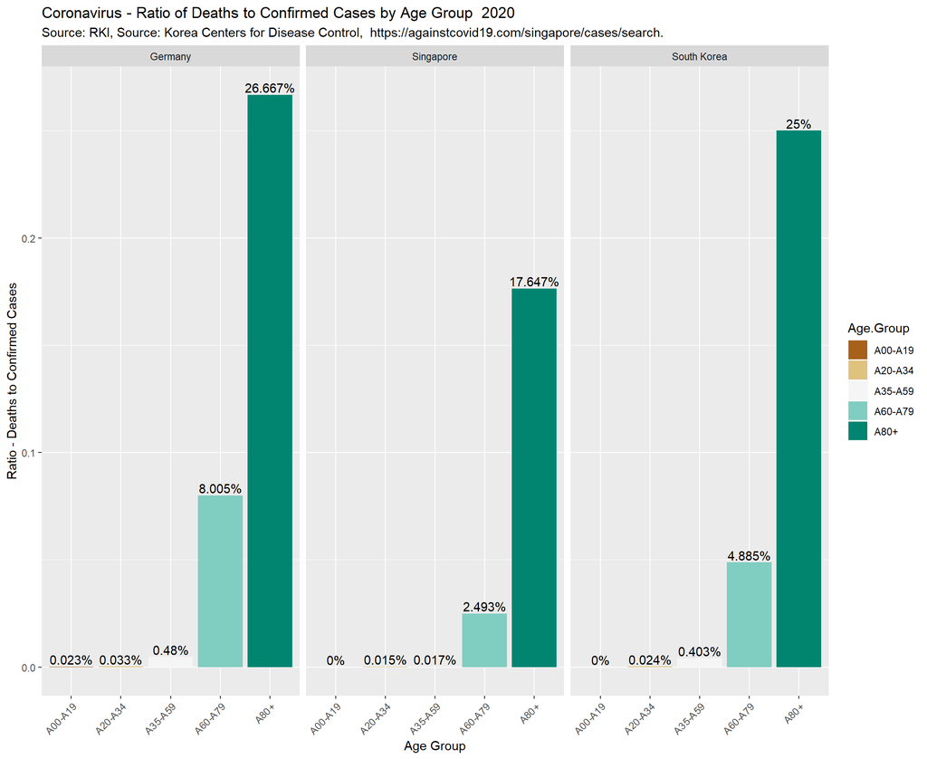

```r
#Start with Germany

#A00-A04 ; A05-A15 and 1/4 of A15-A34 will make it into A00-A19
# 3/4s of A15-A34  will make it into A20-A34
# A35-59 will be A35-A59 so do on

Germany.Cases.Deaths.new = Germany.Cases.Deaths[,c("Age.Group","Number.of.cases", "Number.Death")]

Germany.Cases.newage = data.frame(Age.Group="A00-A19", Number.of.cases= Germany.Cases.Deaths.new[Germany.Cases.Deaths.new$Age.Group=="A00-A04","Number.of.cases"]+Germany.Cases.Deaths.new[Germany.Cases.Deaths.new$Age.Group=="A05-A14","Number.of.cases"]+Germany.Cases.Deaths.new[Germany.Cases.Deaths.new$Age.Group=="A15-A34","Number.of.cases"]/4,Number.Death= Germany.Cases.Deaths.new[Germany.Cases.Deaths.new$Age.Group=="A00-A04","Number.Death"] + Germany.Cases.Deaths.new[Germany.Cases.Deaths.new$Age.Group=="A05-A14","Number.Death"] + Germany.Cases.Deaths.new[Germany.Cases.Deaths.new$Age.Group=="A15-A34","Number.Death"]/4 )


Germany.Cases.newage= rbind(Germany.Cases.newage,data.frame(Age.Group="A20-A34", Number.of.cases= Germany.Cases.Deaths.new[Germany.Cases.Deaths.new$Age.Group=="A15-A34","Number.of.cases"]*3/4,Number.Death=  Germany.Cases.Deaths.new[Germany.Cases.Deaths.new$Age.Group=="A15-A34","Number.Death"]*3/4 ))

Germany.Cases.newage = rbind(Germany.Cases.newage,Germany.Cases.Deaths.new[Germany.Cases.Deaths.new$Age.Group=="A35-A59" | Germany.Cases.Deaths.new$Age.Group=="A60-A79"| Germany.Cases.Deaths.new$Age.Group=="A80+",])

#Ratio of deaths

Germany.Cases.newage$Ratio.death.case = Germany.Cases.newage$Number.Death / Germany.Cases.newage$Number.of.cases
#this exclude 148 cases with unknown ages but zero deaths

#Now let's do something similar for South Korea, with dataframe Korea.Age.Ratio

Korea.Age.Ratio.new = Korea.Age.Ratio[,c("age","confirmed","deceased")]

Korea.Cases.newage = data.frame(Age.Group="A00-A19", Number.of.cases= Korea.Age.Ratio.new[Korea.Age.Ratio.new$age=="0s","confirmed"]+Korea.Age.Ratio.new[Korea.Age.Ratio.new$age=="10s","confirmed"],Number.Death=  Korea.Age.Ratio.new[Korea.Age.Ratio.new$age=="0s","deceased"]+Korea.Age.Ratio.new[Korea.Age.Ratio.new$age=="10s","deceased"])

#For Age group A20-34 require All 20s and half of 30s

Korea.Cases.newage=rbind(Korea.Cases.newage,data.frame(Age.Group="A20-A34", Number.of.cases= Korea.Age.Ratio.new[Korea.Age.Ratio.new$age=="20s","confirmed"]+Korea.Age.Ratio.new[Korea.Age.Ratio.new$age=="30s","confirmed"]/2,Number.Death=  Korea.Age.Ratio.new[Korea.Age.Ratio.new$age=="20s","deceased"]+Korea.Age.Ratio.new[Korea.Age.Ratio.new$age=="30s","deceased"]/2))

Korea.Cases.newage=rbind(Korea.Cases.newage,data.frame(Age.Group="A35-A59", Number.of.cases= Korea.Age.Ratio.new[Korea.Age.Ratio.new$age=="30s","confirmed"]/2+Korea.Age.Ratio.new[Korea.Age.Ratio.new$age=="40s","confirmed"]+Korea.Age.Ratio.new[Korea.Age.Ratio.new$age=="50s","confirmed"],Number.Death=  Korea.Age.Ratio.new[Korea.Age.Ratio.new$age=="30s","deceased"]/2+Korea.Age.Ratio.new[Korea.Age.Ratio.new$age=="40s","deceased"]+Korea.Age.Ratio.new[Korea.Age.Ratio.new$age=="50s","deceased"]))

Korea.Cases.newage=rbind(Korea.Cases.newage,data.frame(Age.Group="A60-A79", Number.of.cases= Korea.Age.Ratio.new[Korea.Age.Ratio.new$age=="60s","confirmed"]+Korea.Age.Ratio.new[Korea.Age.Ratio.new$age=="70s","confirmed"],Number.Death=Korea.Age.Ratio.new[Korea.Age.Ratio.new$age=="60s","deceased"]+Korea.Age.Ratio.new[Korea.Age.Ratio.new$age=="70s","deceased"]))

Korea.Cases.newage=rbind(Korea.Cases.newage,data.frame(Age.Group="A80+", Number.of.cases= Korea.Age.Ratio.new[Korea.Age.Ratio.new$age=="80s","confirmed"],Number.Death=Korea.Age.Ratio.new[Korea.Age.Ratio.new$age=="80s","deceased"]))

Korea.Cases.newage$Ratio.death.case=Korea.Cases.newage$Number.Death / Korea.Cases.newage$Number.of.cases

#Now complete a Similar calculation for Singapore with Singapore.Summary

#replaced Singapore.Summary with on Sep 10 2020 to account for more information gathered from news highlights in Singapore
#Singapore.Summary.elderly
#Singapore.Summary.new = Singapore.Summary[,c("Age_Group","Case","Decesead")]

Singapore.Summary.new = Singapore.Summary.elderly[,c("Age_Group","Case","Decesead")]

Singapore.Cases.newage = data.frame(Age.Group="A00-A19", Number.of.cases= Singapore.Summary.new[Singapore.Summary.new$Age_Group=="0s","Case"]+Singapore.Summary.new[Singapore.Summary.new$Age_Group=="10s","Case"],Number.Death=  Singapore.Summary.new[Singapore.Summary.new$Age_Group=="0s","Decesead"]+Singapore.Summary.new[Singapore.Summary.new$Age_Group=="10s","Decesead"])

Singapore.Cases.newage=rbind(Singapore.Cases.newage,data.frame(Age.Group="A20-A34", Number.of.cases= Singapore.Summary.new[Singapore.Summary.new$Age_Group=="20s","Case"]+Singapore.Summary.new[Singapore.Summary.new$Age_Group=="30s","Case"]/2,Number.Death=  Singapore.Summary.new[Singapore.Summary.new$Age_Group=="20s","Decesead"]+Singapore.Summary.new[Singapore.Summary.new$Age_Group=="30s","Decesead"]/2))

Singapore.Cases.newage=rbind(Singapore.Cases.newage,data.frame(Age.Group="A35-A59", Number.of.cases=Singapore.Summary.new[Singapore.Summary.new$Age_Group=="50s","Case"]+ Singapore.Summary.new[Singapore.Summary.new$Age_Group=="40s","Case"]+Singapore.Summary.new[Singapore.Summary.new$Age_Group=="30s","Case"]/2,Number.Death=  Singapore.Summary.new[Singapore.Summary.new$Age_Group=="50s","Decesead"]+ Singapore.Summary.new[Singapore.Summary.new$Age_Group=="40s","Decesead"]+Singapore.Summary.new[Singapore.Summary.new$Age_Group=="30s","Decesead"]/2))

Singapore.Cases.newage=rbind(Singapore.Cases.newage,data.frame(Age.Group="A60-A79", Number.of.cases=Singapore.Summary.new[Singapore.Summary.new$Age_Group=="60s","Case"]+ Singapore.Summary.new[Singapore.Summary.new$Age_Group=="70s","Case"],Number.Death=  Singapore.Summary.new[Singapore.Summary.new$Age_Group=="60s","Decesead"]+ Singapore.Summary.new[Singapore.Summary.new$Age_Group=="70s","Decesead"]))

Singapore.Cases.newage=rbind(Singapore.Cases.newage,data.frame(Age.Group="A80+", Number.of.cases=Singapore.Summary.new[Singapore.Summary.new$Age_Group=="80s","Case"]+ Singapore.Summary.new[Singapore.Summary.new$Age_Group=="90s","Case"]+Singapore.Summary.new[Singapore.Summary.new$Age_Group=="100s","Case"],Number.Death=  Singapore.Summary.new[Singapore.Summary.new$Age_Group=="80s","Decesead"]+ Singapore.Summary.new[Singapore.Summary.new$Age_Group=="90s","Decesead"]+ Singapore.Summary.new[Singapore.Summary.new$Age_Group=="100s","Decesead"]))

#Ratio
Singapore.Cases.newage$Ratio.death.case=Singapore.Cases.newage$Number.Death / Singapore.Cases.newage$Number.of.cases


#Add country and then bind into single dataframe

Germany.Cases.newage$Country = "Germany"
Korea.Cases.newage$Country = "South Korea"
Singapore.Cases.newage$Country = "Singapore"

Confirmed.Cases.Deaths = rbind(Germany.Cases.newage,Korea.Cases.newage)

Confirmed.Cases.Deaths = rbind(Confirmed.Cases.Deaths,Singapore.Cases.newage)

Confirmed.Cases.Deaths$Percent = paste(round(Confirmed.Cases.Deaths$Ratio.death.case,5)*100,"%",sep="")

ggplot(Confirmed.Cases.Deaths, aes(x=Age.Group, y=Ratio.death.case, fill = Age.Group))+geom_bar(stat="identity") + labs(subtitle="Source: RKI, Source: Korea Centers for Disease Control,  https://againstcovid19.com/singapore/cases/search.",
         title= "Coronavirus - Ratio of Deaths to Confirmed Cases by Age Group  2020") + theme(axis.text.x = element_text(angle = 45, hjust = 1)) + scale_fill_brewer(palette = "BrBG") + xlab("Age Group") + ylab("Ratio - Deaths to Confirmed Cases") + geom_text(aes(label=Percent), position=position_dodge(width=0.9), vjust=-0.25) + facet_wrap(. ~ Country)
```

This should be consider the upper bound, since most like not all confirmed cases were identified.

Another item to take into consideration the mortality rates for A35-A59 in Singapore is because most of causes are for migrant worked in good health and transmitted in dormitories. Probably a better view would be to divide the mortality rates in South Korea and Germany by 2 in order provide an upper limit for the mortality rates in age groups under 60

It will be necessary to review the data for Queens or Brooklyn prior to making decisions about likely mortality rates

https://www1.nyc.gov/site/doh/covid/covid-19-data.page

https://github.com/nychealth/coronavirus-data

Also take into consideration Excess deaths in New York

https://www.cdc.gov/nchs/nvss/vsrr/covid19/excess_deaths.htm

https://data.cdc.gov/

For Excess of Deaths in New York City the following files will be used:

CDC prepared, Excess of Deaths by State Weekly_counts_of_deaths_by_jurisdiction_and_age_group for NY State Aug 21.csv

This is downloaded from the CDC by Age Group and by County. It will give a better perspective of the typical number of deaths for New York City versus the rest of the State Underlying Cause of Death, NY 2018 (1).txt

This provides the number of deaths for New York City in 2020. Could be useful Provisional_COVID-19_Death_Counts_by_Sex__Age__and_State (3)

```r
NY_Deaths_2018 = read.delim("C:/Users/figue/Documents/Coronavirus/Mortality_Study/Underlying Cause of Death, NY 2018 (1).txt", stringsAsFactors = FALSE )

#This file has information by County. Summarize by following Age Groups
#Under 1 year
#1-4 years
#5-14 years
#15-24 years
#25-34 years
#35-44 years
#45-54 years
#55-64 years
#65-74 years
#75-84 years
#85 years and over




NY_Deaths_2018$Age_Num = as.numeric(NY_Deaths_2018$Single.Year.Ages.Code)
#36 NAs, can remove

NY_Deaths_2018=NY_Deaths_2018[!is.na(NY_Deaths_2018$Age_Num),]

#Now  add Age Group

NY_Deaths_2018$Age_Group = ifelse(((NY_Deaths_2018$Age_Num) %/% 5)==0, ifelse(NY_Deaths_2018$Age_Num==0,"0",paste(((NY_Deaths_2018$Age_Num) %/% 5)*5,"-",((NY_Deaths_2018$Age_Num) %/% 5)*5 +4," years",sep="")),paste(((NY_Deaths_2018$Age_Num) %/% 5)*5,"-",((NY_Deaths_2018$Age_Num) %/% 5)*5 +4," years",sep=""))

#Deaths contain the counts of Deaths.
NY_Deaths_2018$Deaths_Num = as.numeric(NY_Deaths_2018$Deaths)

#Now classify New York City versus rest of State

# New York City is Manhattan, Brooklyn, The Bronx, Queens, Staten Island
#They are New York County (Manhattan), Kings County (Brooklyn), Bronx County (The Bronx), Richmond County (Staten Island), and Queens County (Queens).


NY_Deaths_2018$NYC = ifelse(NY_Deaths_2018$County == "Bronx County, NY" | NY_Deaths_2018$County == "Queens County, NY" | NY_Deaths_2018$County == "New York County, NY" | NY_Deaths_2018$County == "Kings County, NY" | NY_Deaths_2018$County == "Richmond County, NY","Yes","No")

#Check NY_Deaths_2018$Age_Group
# No Information between 1 and 30??

##Not good information for people under 30

#check Weekly_counts_of_deaths_by_jurisdiction_and_age_group for NY State Aug 21.csv instead
#This consolidates information of under 25 but this should be good for now.

Excess_Deaths = read.csv("C:/Users/figue/Documents/Coronavirus/Mortality_Study/Weekly_counts_of_deaths_by_jurisdiction_and_age_group for NY State Aug 21.csv", stringsAsFactors = FALSE )
#Predicted (weighted)
#Only New York City and choose one type

Excess_Deaths.NYC = Excess_Deaths[Excess_Deaths[,"ï..Jurisdiction"]=="New York City",]
#just choose one type to not duplicate
Excess_Deaths.NYC=Excess_Deaths.NYC[Excess_Deaths.NYC$Type=="Predicted (weighted)",]
#Changes dates and would like to focus only on March through mid May 2015-2020
#Or which weeks? Weeks 9 to 19 of each year

Excess_Deaths.NYC=Excess_Deaths.NYC[Excess_Deaths.NYC$Week>=9 & Excess_Deaths.NYC$Week<=19,]

#will reduce number of columns, summarize by age group and go Wide on year

Excess_Deaths.NYC.red = Excess_Deaths.NYC[,c("Year","Age.Group","Number.of.Deaths")]

Excess_Deaths.NYC.red=aggregate(Number.of.Deaths ~.,Excess_Deaths.NYC.red,sum )
#Now reshape

Excess_Deaths.NYC.red.wide = reshape(Excess_Deaths.NYC.red, timevar="Year",idvar="Age.Group", direction="wide")

#Calculate mean by Age group

Excess_Deaths.NYC.red.wide$Avg_deaths_2015_2019 = apply(Excess_Deaths.NYC.red.wide[,2:6],1,mean)

Excess_Deaths.NYC.red.wide$Excess_2020 = Excess_Deaths.NYC.red.wide$Number.of.Deaths.2020-Excess_Deaths.NYC.red.wide$Avg_deaths_2015_2019

#Need NYC Population by Age group
#https://www.baruch.cuny.edu/nycdata/population-geography/age_distribution.htm

#this aligned to 25-44 years,45-64 years,65-74 years ,75-84 years , 85 years and older,Under 25 years
c(2733395,2112561,689815,379398,172453,2543695)
```

```
## [1] 2733395 2112561  689815  379398  172453 2543695
```

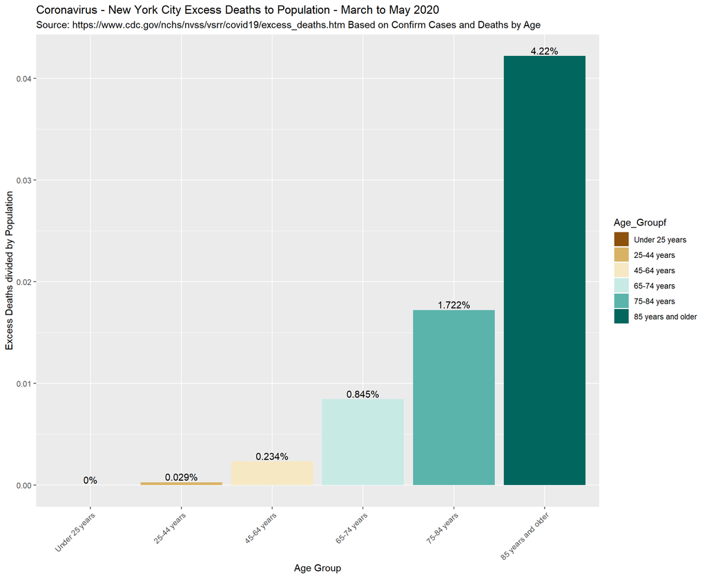

```r
Excess_Deaths.NYC.red.wide$Population = c(2733395,2112561,689815,379398,172453,2543695)
#Excess death ration
Excess_Deaths.NYC.red.wide$Excess_Deatj_Pop_Ratio = Excess_Deaths.NYC.red.wide$Excess_2020/Excess_Deaths.NYC.red.wide$Population

#reorder factors

Excess_Deaths.NYC.red.wide$Age_Groupf <- factor(Excess_Deaths.NYC.red.wide$Age.Group, levels = c("Under 25 years","25-44 years","45-64 years","65-74 years","75-84 years","85 years and older"))

#Percentage

Excess_Deaths.NYC.red.wide$Percent = paste(round(Excess_Deaths.NYC.red.wide$Excess_Deatj_Pop_Ratio,5)*100,"%",sep="")

ggplot(Excess_Deaths.NYC.red.wide, aes(x=Age_Groupf , y=Excess_Deatj_Pop_Ratio, fill = Age_Groupf ))+geom_bar(stat="identity") + labs(subtitle="Source: https://www.cdc.gov/nchs/nvss/vsrr/covid19/excess_deaths.htm Based on Confirm Cases and Deaths by Age",
         title= "Coronavirus - New York City Excess Deaths to Population - March to May 2020") + theme(axis.text.x = element_text(angle = 45, hjust = 1)) + scale_fill_brewer(palette = "BrBG") + xlab("Age Group") + ylab("Excess Deaths divided by Population") + geom_text(aes(label=Percent), position=position_dodge(width=0.9), vjust=-0.25)
```

```r
#Now create a chart for Bergamo Italy, using this same Age Groups

#Bergamo create the 6 groups
#ISTAT_population$Age_Num

ISTAT_population$Age_Group_comp = ifelse(ISTAT_population$Age_Num<25,"Under 25 years",ifelse(ISTAT_population$Age_Num<45,"25-44 years",ifelse(ISTAT_population$Age_Num<65,"45-64 years",ifelse(ISTAT_population$Age_Num<75,"65-74 years",ifelse(ISTAT_population$Age_Num<85,"75-84 years","85 years and older")))))

#Now agregate Bergamo Population by Age Group

Bergamo.Pop = aggregate(Value~Age_Group_comp,data=ISTAT_population,sum)

#Check total Population
sum(Bergamo.Pop$Value)
```

```
## [1] 1116384
```

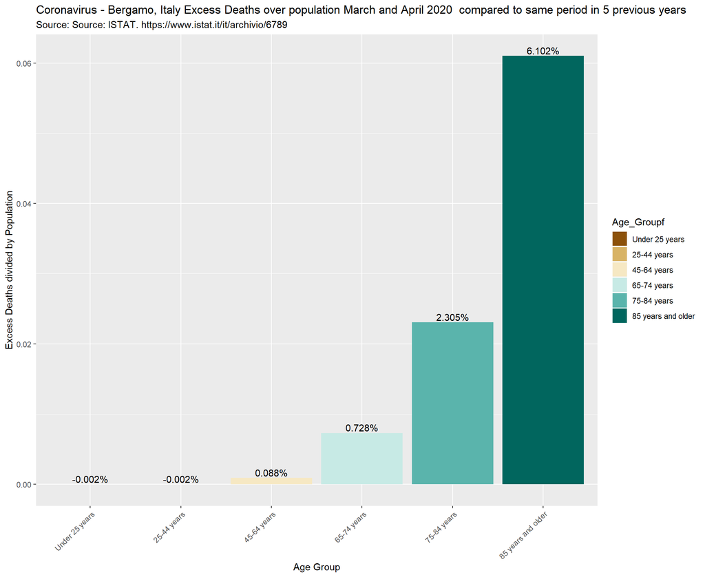

```r
#Deaths in Bergamo Excess Deaths. Original Groups given by Deaths.Bergamo$CL_ETA
#Have to align to "Under 25 years","25-44 years","45-64 years","65-74 years","75-84 years","85 years and older"

#Initialize
Deaths.Bergamo$Age_Group_com= NA

Deaths.Bergamo[Deaths.Bergamo$Age_Group=="0" | Deaths.Bergamo$Age_Group=="0-4 years" | Deaths.Bergamo$Age_Group=="5-9 years" | Deaths.Bergamo$Age_Group=="10-14 years" | Deaths.Bergamo$Age_Group=="15-19 years" | Deaths.Bergamo$Age_Group=="20-24 years","Age_Group_com"]="Under 25 years"

Deaths.Bergamo[Deaths.Bergamo$Age_Group=="25-29 years" | Deaths.Bergamo$Age_Group=="30-34 years" | Deaths.Bergamo$Age_Group=="35-39 years" | Deaths.Bergamo$Age_Group=="40-44 years" ,"Age_Group_com"]="25-44 years"


Deaths.Bergamo[Deaths.Bergamo$Age_Group=="45-49 years" | Deaths.Bergamo$Age_Group=="50-54 years" | Deaths.Bergamo$Age_Group=="55-59 years" | Deaths.Bergamo$Age_Group=="60-64 years" ,"Age_Group_com"]="45-64 years"

Deaths.Bergamo[Deaths.Bergamo$Age_Group=="65-69 years" | Deaths.Bergamo$Age_Group=="70-74 years" ,"Age_Group_com"]="65-74 years"

Deaths.Bergamo[Deaths.Bergamo$Age_Group=="75-79 years" | Deaths.Bergamo$Age_Group=="80-84 years" ,"Age_Group_com"]="75-84 years"

Deaths.Bergamo[Deaths.Bergamo$Age_Group=="85-89 years" | Deaths.Bergamo$Age_Group=="90-94 years" | Deaths.Bergamo$Age_Group=="95-99 years" | Deaths.Bergamo$Age_Group=="100-104 years" ,"Age_Group_com"]="85 years and older"

#Have to aggregate by group


Deaths.Bergamo.Summary = aggregate(cbind(T_15,T_16,T_17,T_18,T_19,T_20) ~ Age_Group_com,data=Deaths.Bergamo, sum)

#Calculate average of last 5 years and then obtain excess deaths comapared to 2020
Deaths.Bergamo.Summary$Avg_15_2019 = apply(Deaths.Bergamo.Summary[,c("T_15","T_16","T_17","T_18","T_19")],1,mean)

Deaths.Bergamo.Summary$Excess_2020 = Deaths.Bergamo.Summary$T_20 - Deaths.Bergamo.Summary$Avg_15_2019

#Now merge with population and calculate ration of excess deaths to popuation

Deaths.Bergamo.Summary=merge(Deaths.Bergamo.Summary,Bergamo.Pop,by.x="Age_Group_com",by.y="Age_Group_comp", all.x=TRUE, all.y=FALSE)

Deaths.Bergamo.Summary$Excess_D_over_Pop = Deaths.Bergamo.Summary$Excess_2020 / Deaths.Bergamo.Summary$Value



#reorder factors




Deaths.Bergamo.Summary$Age_Groupf <- factor(Deaths.Bergamo.Summary$Age_Group_com, levels = c("Under 25 years","25-44 years","45-64 years","65-74 years","75-84 years","85 years and older"))


#Percentage

Deaths.Bergamo.Summary$Percent = paste(round(Deaths.Bergamo.Summary$Excess_D_over_Pop,5)*100,"%",sep="")



ggplot(Deaths.Bergamo.Summary, aes(x=Age_Groupf , y=Excess_D_over_Pop, fill = Age_Groupf ))+geom_bar(stat="identity") + labs(subtitle="Source: Source: ISTAT. https://www.istat.it/it/archivio/6789",
         title= "Coronavirus - Bergamo, Italy Excess Deaths over population March and April 2020  compared to same period in 5 previous years") + theme(axis.text.x = element_text(angle = 45, hjust = 1)) + scale_fill_brewer(palette = "BrBG") + xlab("Age Group") + ylab("Excess Deaths divided by Population") + geom_text(aes(label=Percent), position=position_dodge(width=0.9), vjust=-0.25)
```

```r
##Have to double check Excess Deaths in New York seem really high
#Many more than the ones reported by COVID statistics
```